# Initial Protein Filtering

This notebook takes input files from IDPicker and generates a final list of VIR-CLASP hits (“binding proteins”) by applying filters to the list. Here is a brief summary of the filtering steps:

0. Ensure proteins have >= 2 unique peptides and >= 20% sequence coverage (not included in Sankey)
1. Remove proteins that are not present in all 3 experimental replicates
2. Remove proteins that are part of the CRAPome list of common mass-spec contaminants. -Experiment IDs used to generate CRAPome list are: CC405, CC406, CC410 -CRAPome list narrowed to proteins with an average spectra in the 3 experiments of >=2
3. Remove proteins that are present in both control samples

```r
library(tidyverse)
library(here)
library(networkD3)
#Function definitions
read_files <- function(file_name) {
  temp <- read_tsv(here("Input", file_name), progress = FALSE) %>%
    select("Accession", "Description", "Filtered Spectra", "Distinct Peptides", "Coverage") %>%
    mutate(source = str_replace(file_name, "\\.tsv", ""))
}
```

## Input of data files

-Split into Experimental (Exp) and no4SU control (Ctr) samples -Remove decoys -Perform Filter 0 -Clean up the Accessions -Generate a histogram of Filtered Spectra and a count of total experimental proteins and control proteins. Log transform because of high number of low counts

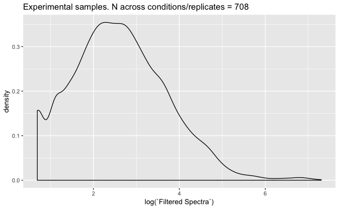

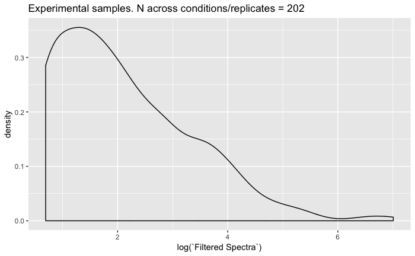

## Filter 1: Remove proteins that are not present in all 3 experimental replicates

```r
filter1 <- filter0_Exp %>%
  separate(col = "source", into = c("Timepoint", "IFN", "Replicate"), sep = "_") %>%
  group_by(Timepoint, IFN, Accession) %>%
  mutate(exists = sum(`Filtered Spectra` > 0)) %>%
  select(-`Filtered Spectra`, -Replicate) %>%
  filter(exists == 3) %>%
  select(-exists) %>%
  unique()
print(paste("Number of unique proteins after Filter 1: ", n_distinct(filter1$Accession)))
```

```
[1] "Number of unique proteins after Filter 1:  469"
```

## Filter 2: Remove proteins that are part of the CRAPome list of common mass-spec contaminants.

-Read in CRAPome file, then remove entries with fewer than 2 average spectral counts

```r
crapome <- read_csv(here("Crapome.csv")) %>%
  filter(AVE_SC >= 2)
filter2 <- filter1 %>%
  filter(!(ID %in% crapome$UNIPROT_ID))
print(paste("Number of unique proteins after Filter 2: ", n_distinct(filter2$Accession)))
```

```
[1] "Number of unique proteins after Filter 2:  330"
```

## Filter 3: Remove proteins that are present in both control samples

```r
Ctr_minus <- filter0_Ctr %>%
  separate(col = "source", into = c("Trash", "IFN", "Replicate"), sep = "_") %>%
  filter(IFN == "minus") %>%
  select(-Trash, -IFN) %>%
  group_by(Accession) %>%
  mutate(exists = sum(`Filtered Spectra` > 0)) %>%
  filter(exists == 2)
Ctr_plus <- filter0_Ctr %>%
  separate(col = "source", into = c("Trash", "IFN", "Replicate"), sep = "_") %>%
  filter(IFN == "plus") %>%
  select(-Trash, -IFN) %>%
  group_by(Accession) %>%
  mutate(exists = sum(`Filtered Spectra` > 0)) %>%
  filter(exists == 2)
filter3_minus <- filter2 %>%
  filter(IFN == "minus") %>%
  filter(!(Accession %in% Ctr_minus$Accession))
filter3_plus <- filter2 %>%
  filter(IFN == "plus") %>%
  filter(!(Accession %in% Ctr_minus$Accession))
filter3 <- bind_rows(filter3_minus, filter3_plus)
print(paste("Number of unique proteins after Filter 3: ", n_distinct(filter3$Accession)))
```

```
[1] "Number of unique proteins after Filter 3:  308"
```

## Sankey generation

-Code adapted from: https://www.r-graph-gallery.com/321-introduction-to-interactive-sankey-diagram-2/

```r
# 1 ------ CONNECTION DATA FRAME

# Usually what you have is a connection data frame: a list of flows with intensity for each flow
links=data.frame(source=c("Unfiltered","Unfiltered",
                          "In all replicates", "In all replicates",
                          "Not in CRAPome", "Not in CRAPome"),
                 target=c("In all replicates","Not in all replicates", "Not in CRAPome", "CRAPome known contaminant", "Final Dataset", "ID'ed in negative control"),
                 value=c(n_distinct(filter1$Accession),
                         (n_distinct(filter0_Exp$Accession) - n_distinct(filter1$Accession)),
                         n_distinct(filter2$Accession),
                         (n_distinct(filter1$Accession) - n_distinct(filter2$Accession)),
                         n_distinct(filter3$Accession),
                         n_distinct(filter2$Accession) - n_distinct(filter3$Accession)))

# From these flows we need to create a node data frame: it lists every entities involved in the flow
nodes=data.frame(name=c(as.character(links$source), as.character(links$target)) %>% unique())

# With networkD3, connection must be provided using id, not using real name like in the links dataframe.. So we need to reformat it.
links$IDsource=match(links$source, nodes$name)-1
links$IDtarget=match(links$target, nodes$name)-1

# Make the Network
sankeyNetwork(Links = links, Nodes = nodes,
              Source = "IDsource", Target = "IDtarget",
              Value = "value", NodeID = "name",
              fontSize = 15, nodeWidth = 30,
              units = "Proteins", sinksRight=FALSE)
```

[interactive chart not shown]